# Practical Machine Learning

Given that we are looking to predict a categorical variable, it was appropriate to use the random forest algorithm in order to predict the outcome.

To simplify the model, I made the decision to remove any variables which I considered superfluous to the project. For example, I removed the timestamp and user name variables.

I also removed the variables which largely had NAs or blanks as these would add nothing to the model.

```r
set.seed(1333)
library(caret)
library(randomForest)
training<-read.csv("pml-training.csv")
xtraining<-training[,-c(1,2,3,4,5,6,7,12:36,50:59,69:83,87:101,103:112,125:139,141:150)]
xtraining$classe<-as.factor(xtraining$classe)
```

After the removal of these variables, I was left with 53 variables on which to continue the model training.

In terms of cross-validation, I employed the function trainControl in order to specify repeated K-fold cross-validation. The number of folds used was 10, and this was repeated 10 times.

```r
fitControl<-trainControl(method="repeatedcv", number=10, repeats=10)
```

Using the function randomForest, I first ran the model using all variables. I included the importance option in the model. This allowed me to produce the following graph which listed the variable importance as described by a Random Forest.

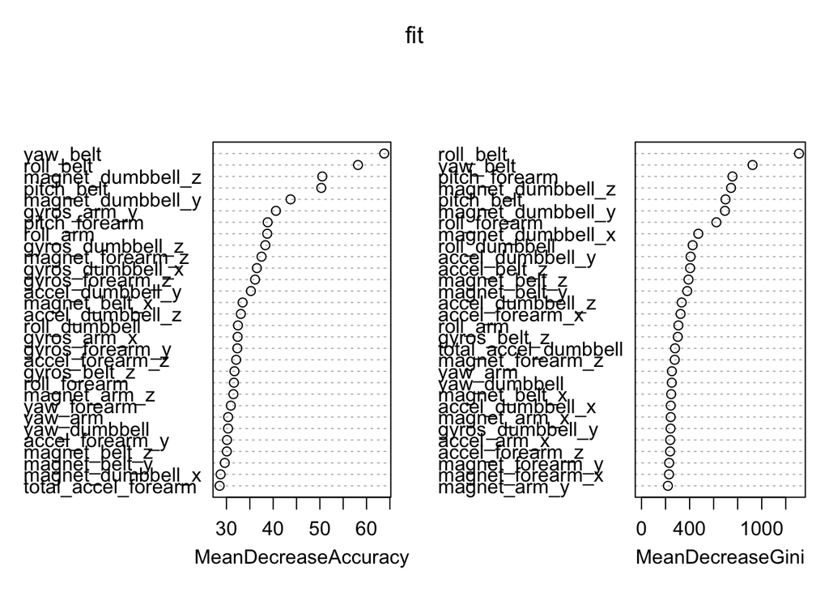

```r
fit <- randomForest(classe ~ ., data=xtraining, importance = TRUE, trControl = fitControl)
varImpPlot(fit)
```

Based on the above graph, I included the following variables in a new model: yaw_belt + roll_belt + magnet_dumbbell_z + magnet_dumbbell_y + pitch_belt + pitch_forearm + gyros_arm_y

```r
fit2 <- randomForest(classe ~ yaw_belt + roll_belt + magnet_dumbbell_z + magnet_dumbbell_y + pitch_belt + pitch_forearm + gyros_arm_y,   data=xtraining, importance = TRUE, trControl = fitControl)
```

```r
fit2
```

```
##
## Call:
##  randomForest(formula = classe ~ yaw_belt + roll_belt + magnet_dumbbell_z +      magnet_dumbbell_y + pitch_belt + pitch_forearm + gyros_arm_y,      data = xtraining, importance = TRUE, trControl = fitControl)
##                Type of random forest: classification
##                      Number of trees: 500
## No. of variables tried at each split: 2
##
##         OOB estimate of  error rate: 1.04%
## Confusion matrix:
##      A    B    C    D    E class.error
## A 5537   14   16    9    4    0.007706
## B   23 3725   43    5    1    0.018962
## C    6   10 3392   14    0    0.008767
## D    2    1   22 3186    5    0.009328
## E    0   16    8    6 3577    0.008317
```